```python
import pandas as pd
import matplotlib.pyplot as plt
import seaborn as sns
import numpy as np
import itertools
import timeit
import datetime as dt

%matplotlib inline
```

# 1. Data Loading and Preprocessing

### Data Loading

```python
# Load data
support_df = pd.read_csv("data/support.csv")
voters_df = pd.read_csv("data/voters.csv")
graph_df = pd.read_csv("data/graph.csv")
```

### Check duplicates and missing values

```python
voters_df.head(2)
```

|  | prim_id | la1 | la3 | voted_03_05_2013 | voted_05_21_2013 | voted_06_07_2016 | demplus | age | repplus | party | abrscore | hpt_nt | ismarried | home | renters | ethnic | sex | hhcount |
| --- | --- | --- | --- | --- | --- | --- | --- | --- | --- | --- | --- | --- | --- | --- | --- | --- | --- | --- |
| 0 | 19101063480 | 0 | 1 | 1 | 0 | 1 | N | 42.0 | Y | R | ML | S | Y | H | N | X | M | 3 |
| 1 | 19101122779 | 0 | 0 | 0 | 0 | 1 | Y | 53.0 | N | D | NaN | A | N | NaN | N | X | M | 1 |

```python
print(voters_df.shape)
print(len(voters_df['prim_id'].unique()))
```

```
(434624, 18)
434624
```

```python
voters_df.isnull().sum()
```

```
prim_id                  0
la1                      0
la3                      0
voted_03_05_2013         0
voted_05_21_2013         0
voted_06_07_2016         0
demplus                  0
age                     84
repplus                  0
party                    0
abrscore            290126
hpt_nt                   0
ismarried                0
home                270644
renters                  0
ethnic              105261
sex                  19242
hhcount                  0
dtype: int64
```

```python
support_df.head(2)
```

|  | prim_id | support |
| --- | --- | --- |
| 0 | 19523066036 | candidate_b |
| 1 | 19523244550 | candidate_b |

```python
print (support_df.shape)
print (len(support_df.prim_id.unique()))
```

```
(1577, 2)
1577
```

```python
graph_df.head(2)
```

|  | relationship_score | source | sink |
| --- | --- | --- | --- |
| 0 | 1.0 | 19523849390 | 19522824197 |
| 1 | 1.0 | 19527100653 | 19522824197 |

```python
support_df.isnull().sum()
```

```
prim_id    0
support    0
dtype: int64
```

```python
graph_df.duplicated(['source', 'sink']).sum()
```

```
0
```

**Finding**

- have missing value in voters data, not in graph and support data
- no duplicates

### Data Preprocessing

I'll perform a minimum data preprocessing before exploration. More cleaning will be done after the exploration.

```python
# merge support and voters data
df = pd.merge(support_df, voters_df, on=['prim_id'], how='left')
df.isnull().sum()
```

```
prim_id               0
support               0
la1                   0
la3                   0
voted_03_05_2013      0
voted_05_21_2013      0
voted_06_07_2016      0
demplus               0
age                   0
repplus               0
party                 0
abrscore            678
hpt_nt                0
ismarried             0
home                768
renters               0
ethnic              374
sex                  22
hhcount               0
dtype: int64
```

```python
def clean_missing_category(df):
    """
    Fill categorical missing value in abrscore, home, ethnic and sex.
    """
    df.loc[df.abrscore.isnull(), 'abrscore'] = "NOT_ABR" # Not Absentee Ballot Return
    df.loc[df.home.isnull(), 'home'] = "N" # not home owner
    df.loc[df.ethnic.isnull(), 'ethnic'] = "NN" # not known
    #df.loc[df.sex.isnull(), 'sex'] = "NN" # not know
```

```python
clean_missing_category(df)
df.head()
```

|  | prim_id | support | la1 | la3 | voted_03_05_2013 | voted_05_21_2013 | voted_06_07_2016 | demplus | age | repplus | party | abrscore | hpt_nt | ismarried | home | renters | ethnic | sex | hhcount |
| --- | --- | --- | --- | --- | --- | --- | --- | --- | --- | --- | --- | --- | --- | --- | --- | --- | --- | --- | --- |
| 0 | 19523066036 | candidate_b | 0 | 1 | 0 | 0 | 1 | Y | 51.0 | N | D | NOT_ABR | A | N | H | Y | X | M | 1 |
| 1 | 19523244550 | candidate_b | 0 | 0 | 0 | 0 | 1 | Y | 53.0 | N | D | NOT_ABR | A | Y | N | Y | X | M | 1 |
| 2 | 19491481087 | candidate_a | 0 | 0 | 0 | 0 | 0 | N | 59.0 | Y | R | NOT_ABR | S | N | H | Y | S | M | 2 |
| 3 | 19526211987 | candidate_a | 0 | 0 | 0 | 0 | 1 | Y | 23.0 | N | D | OL | B | N | H | N | J | M | 5 |
| 4 | 19214836641 | candidate_a | 1 | 1 | 1 | 1 | 1 | N | 79.0 | Y | R | OL | R | N | N | Y | X | F | 1 |

# 2. Data Exploration

### Class balance in support data

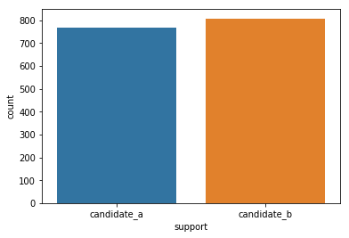

```python
sns.countplot(x='support', order=['candidate_a','candidate_b'], data=df)
```

**Observation:** This is a balanced dataset

### Explore Categorical Features

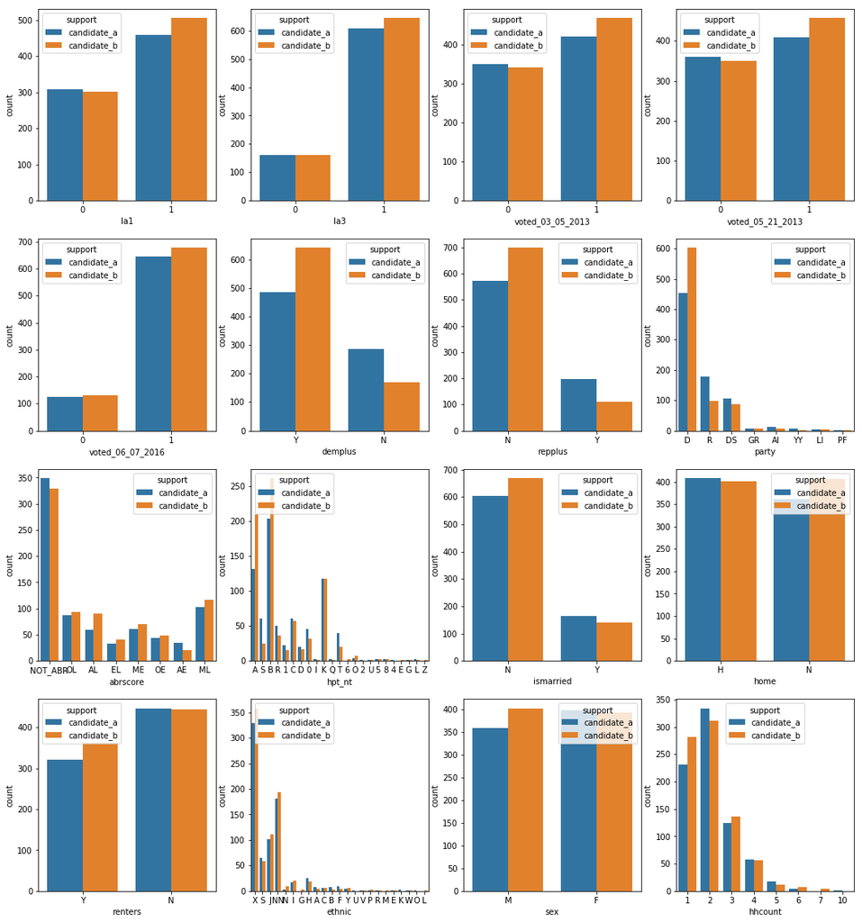

```python
features_ = [x for x in df.columns if x not in ['prim_id', 'support', 'age']]

nrows = 4
ncols = 4
fig, ax = plt.subplots(nrows, ncols, figsize=(18, 20))

i = 0
for row in range(nrows):
    for col in range(ncols):
        sns.countplot(x=features_[i], hue="support", hue_order=['candidate_a', 'candidate_b'], data=df, ax=ax[row][col])
        i += 1
```

### Explore Age Distribution

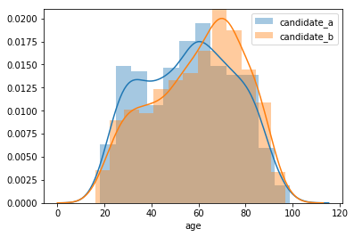

```python
f, ax = plt.subplots(1, 1)
sns.distplot(df['age'][df['support']=='candidate_a'], label='candidate_a')
sns.distplot(df['age'][df['support']=='candidate_b'], label='candidate_b')
ax.legend()
```

**Some Observations:**

- frequent voters and voters voted in 03/05/2013, 05/21/2013 and 06/07/2016 support candidate_b slightly higher than candidate_a.
- More voters from demplus and party_D support candidate_b than candidate_a
- More voters not from repplus support candidate_b than candidate_a, more voters from party_R support candidate_a than candidate_b.
- This implies candidate_a might be a republican candidate, and candidate_b might be a democrat candidate.
- More unmarried voters and rental voters support candidate_b.
- Voters have overlapped age distributions, candidate_a have more younger supporters.
- All above differences are not significant.

### Feature Correlations

```python
def binary_category_to_numeric(df):
    """
    Change binary category data to 0/1 numeric features.
    """
    df['support'] = df['support'].map({'candidate_b':0, 'candidate_a':1}) # 0 for support b, 1 for a
    df['demplus'] = df['demplus'].map({'N':0, 'Y':1}) # 0 for N, 1 for Y
    df['repplus'] = df['repplus'].map({'N':0, 'Y':1}) # 0 for N, 1 for Y
    df['ismarried'] = df['ismarried'].map({'N':0, 'Y':1}) # 0 for N, 1 for Y
    df['home'] = df['home'].map({'N':0, 'H':1}) # 0 for N, 1 for H
    df['renters'] = df['renters'].map({'N':0, 'Y':1}) # 0 for N, 1 for Y
    df['sex'] = df['sex'].map({'F':0, 'M':1}) # 0 for F, 1 for M
```

```python
binary_category_to_numeric(df)
df.head()
```

|  | prim_id | support | la1 | la3 | voted_03_05_2013 | voted_05_21_2013 | voted_06_07_2016 | demplus | age | repplus | party | abrscore | hpt_nt | ismarried | home | renters | ethnic | sex | hhcount |
| --- | --- | --- | --- | --- | --- | --- | --- | --- | --- | --- | --- | --- | --- | --- | --- | --- | --- | --- | --- |
| 0 | 19523066036 | 0 | 0 | 1 | 0 | 0 | 1 | 1 | 51.0 | 0 | D | NOT_ABR | A | 0 | 1 | 1 | X | 1.0 | 1 |
| 1 | 19523244550 | 0 | 0 | 0 | 0 | 0 | 1 | 1 | 53.0 | 0 | D | NOT_ABR | A | 1 | 0 | 1 | X | 1.0 | 1 |
| 2 | 19491481087 | 1 | 0 | 0 | 0 | 0 | 0 | 0 | 59.0 | 1 | R | NOT_ABR | S | 0 | 1 | 1 | S | 1.0 | 2 |
| 3 | 19526211987 | 1 | 0 | 0 | 0 | 0 | 1 | 1 | 23.0 | 0 | D | OL | B | 0 | 1 | 0 | J | 1.0 | 5 |
| 4 | 19214836641 | 1 | 1 | 1 | 1 | 1 | 1 | 0 | 79.0 | 1 | R | OL | R | 0 | 0 | 1 | X | 0.0 | 1 |

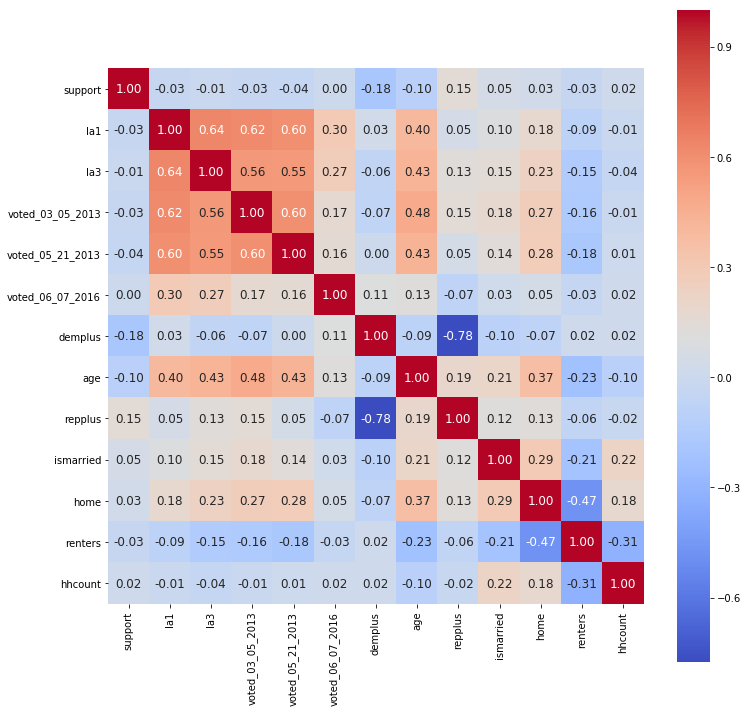

```python
# check the correlation between features
# features_ exclude non-binary categories
features_ = [x for x in df.columns if x not in ['prim_id', 'party', 'abrscore', 'hpt_nt', 'ethnic', 'sex']]

corr = df[features_].corr() # .corr is used for find corelation
plt.figure(figsize=(12,12))
sns.heatmap(corr, cbar = True, square = True, annot=True, fmt= '.2f', annot_kws={'size': 12},
            xticklabels= features_, yticklabels= features_, cmap= 'coolwarm')
```

# 3. Modeling (without graph features)

## 3.1 One-Hot Encoding and PCA

```python
# set missing sex as 0.5
df.loc[df.sex.isnull(), 'sex'] = 0.5 # not known
```

### One-Hot Encoding

```python
# One hot encoding
df = pd.get_dummies(df)
df.columns
```

```
Index(['prim_id', 'support', 'la1', 'la3', 'voted_03_05_2013',
       'voted_05_21_2013', 'voted_06_07_2016', 'demplus', 'age', 'repplus',
       'ismarried', 'home', 'renters', 'sex', 'hhcount', 'party_AI', 'party_D',
       'party_DS', 'party_GR', 'party_LI', 'party_PF', 'party_R', 'party_YY',
       'abrscore_AE', 'abrscore_AL', 'abrscore_EL', 'abrscore_ME',
       'abrscore_ML', 'abrscore_NOT_ABR', 'abrscore_OE', 'abrscore_OL',
       'hpt_nt_0', 'hpt_nt_1', 'hpt_nt_2', 'hpt_nt_4', 'hpt_nt_5', 'hpt_nt_6',
       'hpt_nt_8', 'hpt_nt_A', 'hpt_nt_B', 'hpt_nt_C', 'hpt_nt_D', 'hpt_nt_E',
       'hpt_nt_G', 'hpt_nt_I', 'hpt_nt_K', 'hpt_nt_L', 'hpt_nt_O', 'hpt_nt_Q',
       'hpt_nt_R', 'hpt_nt_S', 'hpt_nt_T', 'hpt_nt_U', 'hpt_nt_Z', 'ethnic_A',
       'ethnic_B', 'ethnic_C', 'ethnic_E', 'ethnic_F', 'ethnic_G', 'ethnic_H',
       'ethnic_I', 'ethnic_J', 'ethnic_K', 'ethnic_L', 'ethnic_M', 'ethnic_N',
       'ethnic_NN', 'ethnic_O', 'ethnic_P', 'ethnic_R', 'ethnic_S', 'ethnic_U',
       'ethnic_V', 'ethnic_W', 'ethnic_X', 'ethnic_Y'],
      dtype='object')
```

### PCA: see if data is linearly separable in a lower dimensional space

```python
from sklearn.preprocessing import StandardScaler
from sklearn.decomposition import PCA

X = df.dropna().drop(["prim_id",'support'], axis=1)
Y = df['support']

scaler = StandardScaler().fit(X)
X = pd.DataFrame(scaler.transform(X), columns = X.columns)

pca = PCA(5)
pca.fit(X)

X_pca = pca.transform(X)
print(X_pca.shape)

df_pca5 = pd.DataFrame(np.column_stack([X_pca, Y]), columns=['PCA '+str(x) for x in range(1,6)]+['support'] )
df_pca5.head()
```

```
(1577, 5)
```

|  | PCA 1 | PCA 2 | PCA 3 | PCA 4 | PCA 5 | support |
| --- | --- | --- | --- | --- | --- | --- |
| 0 | -1.861989 | 0.782948 | -1.228593 | -1.124998 | 0.117578 | 0.0 |
| 1 | -2.309465 | 1.646784 | -0.786441 | -1.401418 | 0.122192 | 0.0 |
| 2 | 2.511896 | 4.155133 | 0.991690 | -2.582846 | 0.009581 | 1.0 |
| 3 | -2.352359 | 0.793839 | 3.482679 | -0.496135 | 0.277860 | 1.0 |
| 4 | 4.069722 | 0.618058 | -2.147955 | -1.993185 | -0.287372 | 1.0 |

```python
pca.explained_variance_ratio_
```

```
array([ 0.06155176,  0.05077807,  0.03167505,  0.02861035,  0.02650845])
```

[figure not shown]

```python
sns.pairplot(df_new, hue="support", size=3)
```

**In the above pair-plots, It shows that the dataset can not be linearly separated. So I won't use linear algorithms to build model.**

## 3.2 Random Forest Model

- Random Forest is effective at discovering nonlinear relationships.
- Random Forest has better interpretability, can help us get insight of feature importance.
- Random Forest is fast and no feature selection is needed at current stage.
- Can use predict probability (predict_proba) to give out class probability results for candidate A.

### Train Test Split

```python
from sklearn.model_selection import train_test_split

train, test = train_test_split(df, test_size=0.2, random_state=10
                                     ,stratify=df['support'])# stratify the outcome

features = [x for x in train.columns if x not in ['prim_id', 'support']]

X_train = train[features]
X_test = test[features]
y_train = train['support']
y_test = test['support']
```

### Grid Search with Cross Validation

```python
from sklearn.grid_search import GridSearchCV
from sklearn.ensemble import RandomForestClassifier

clf_rf = RandomForestClassifier(n_jobs=-1, max_features='sqrt', random_state=0)

# Use a grid over parameters of interest
param_grid = {
           "n_estimators" : [50, 100, 150, 200],
           "max_depth" : [5, 10, 20, 30],
           "min_samples_leaf" : [1, 3, 5]}

rf_cv = GridSearchCV(estimator=clf_rf, param_grid=param_grid, cv= 5)
rf_cv.fit(X_train, y_train)
```

```
GridSearchCV(cv=5, error_score='raise',
       estimator=RandomForestClassifier(bootstrap=True, class_weight=None, criterion='gini',
            max_depth=None, max_features='sqrt', max_leaf_nodes=None,
            min_impurity_decrease=0.0, min_impurity_split=None,
            min_samples_leaf=1, min_samples_split=2,
            min_weight_fraction_leaf=0.0, n_estimators=10, n_jobs=-1,
            oob_score=False, random_state=0, verbose=0, warm_start=False),
       fit_params={}, iid=True, n_jobs=1,
       param_grid={'n_estimators': [50, 100, 150, 200], 'max_depth': [5, 10, 20, 30], 'min_samples_leaf': [1, 3, 5]},
       pre_dispatch='2*n_jobs', refit=True, scoring=None, verbose=0)
```

```python
clf_rf_best = rf_cv.best_estimator_
clf_rf_best
```

```
RandomForestClassifier(bootstrap=True, class_weight=None, criterion='gini',
            max_depth=10, max_features='sqrt', max_leaf_nodes=None,
            min_impurity_decrease=0.0, min_impurity_split=None,
            min_samples_leaf=3, min_samples_split=2,
            min_weight_fraction_leaf=0.0, n_estimators=150, n_jobs=-1,
            oob_score=False, random_state=0, verbose=0, warm_start=False)
```

```python
y_predicted_rf = clf_rf_best.predict(X_test)
```

```python
from sklearn.metrics import accuracy_score, f1_score, precision_score, recall_score, classification_report

def get_metrics(y_test, y_predicted):
    """
    Return metric scores for the classification model.
    """
    # true positives / (true positives+false positives)
    precision = precision_score(y_test, y_predicted, pos_label=None,
                                    average='weighted')
    # true positives / (true positives + false negatives)
    recall = recall_score(y_test, y_predicted, pos_label=None,
                              average='weighted')

    # harmonic mean of precision and recall
    f1 = f1_score(y_test, y_predicted, pos_label=None, average='weighted')

    # true positives + true negatives/ total
    accuracy = accuracy_score(y_test, y_predicted)
    return accuracy, precision, recall, f1
```

```python
accuracy, precision, recall, f1 = get_metrics(y_test, y_predicted_rf)
print("accuracy = %.3f, precision = %.3f, recall = %.3f, f1 = %.3f" % (accuracy, precision, recall, f1))
```

```
accuracy = 0.573, precision = 0.572, recall = 0.573, f1 = 0.572
```

### Feature Importance

```python
def plot_feature_importance(model, features, X_train, n_feature_plot, size):
    """
    Plot feature importance.

    param n_features_plot: how many features in the final plot.
    """
    importances = model.feature_importances_
    indices = np.argsort(importances)[::-1]
    indices_plot = indices[:n_feature_plot]

    # Print the feature ranking
    print("Feature ranking:")

    for f in range(X_train.shape[1]):
        print("%d. feature %s (%f)" % (f + 1, features[indices[f]], importances[indices[f]]))

    # Plot the feature importances of the forest
    plt.figure(figsize=(10,10))
    plt.title("Feature importances",size=16)
    plt.barh(range(n_feature_plot), importances[indices_plot], color="steelblue", align="center")
    plt.yticks(range(n_feature_plot), [features[index] for index in indices_plot], size=14), #{'rotate':45})
    plt.ylim([n_feature_plot,-1])
    plt.xticks(size=12)
    plt.show()
```

```
Feature ranking:
1. feature age (0.183434)
2. feature hhcount (0.056971)
3. feature sex (0.042298)
4. feature demplus (0.041986)
5. feature party_D (0.036730)
6. feature renters (0.030528)
7. feature home (0.029729)
8. feature ethnic_X (0.029501)
9. feature voted_03_05_2013 (0.029162)
10. feature ismarried (0.028662)
11. feature voted_05_21_2013 (0.028488)
12. feature repplus (0.027426)
13. feature la1 (0.026135)
14. feature abrscore_NOT_ABR (0.025941)
15. feature party_R (0.025789)
16. feature ethnic_NN (0.022721)
17. feature voted_06_07_2016 (0.022474)
18. feature abrscore_AL (0.022420)
19. feature abrscore_ML (0.022048)
20. feature hpt_nt_A (0.020534)
21. feature hpt_nt_B (0.016280)
22. feature ethnic_J (0.015858)
23. feature la3 (0.015823)
24. feature hpt_nt_K (0.015676)
25. feature abrscore_OL (0.015422)
26. feature ethnic_S (0.014701)
27. feature hpt_nt_S (0.014495)
28. feature abrscore_ME (0.013635)
29. feature party_DS (0.012798)
30. feature abrscore_EL (0.011399)
31. feature abrscore_OE (0.011350)
32. feature abrscore_AE (0.011347)
33. feature hpt_nt_0 (0.010741)
34. feature hpt_nt_C (0.010341)
35. feature hpt_nt_T (0.009200)
36. feature ethnic_H (0.008406)
37. feature hpt_nt_R (0.008326)
38. feature hpt_nt_D (0.005593)
39. feature ethnic_I (0.004485)
```

[output cut: 21 more lines]

```
61. feature ethnic_P (0.000000)
62. feature ethnic_O (0.000000)
63. feature hpt_nt_Q (0.000000)
64. feature hpt_nt_2 (0.000000)
65. feature ethnic_L (0.000000)
66. feature ethnic_K (0.000000)
67. feature hpt_nt_L (0.000000)
68. feature hpt_nt_4 (0.000000)
69. feature hpt_nt_G (0.000000)
70. feature party_PF (0.000000)
71. feature hpt_nt_E (0.000000)
72. feature ethnic_E (0.000000)
73. feature hpt_nt_6 (0.000000)
74. feature ethnic_G (0.000000)
75. feature hpt_nt_I (0.000000)
```

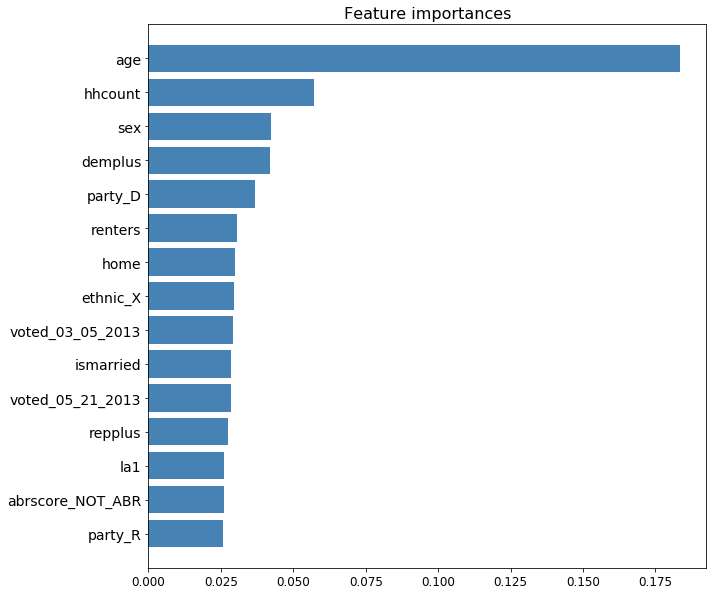

```python
plot_feature_importance(clf_rf_best, X_train.columns, X_train, 15, 8)
```

### Model Evalutation

```python
from sklearn.metrics import roc_curve, auc

def plot_roc_curve(model, X_test, size):

    y_prob = model.predict_proba(X_test)[:,1]

    fpr, tpr, thresholds = roc_curve(y_test, y_prob, pos_label=1)
    auc_score = auc(fpr,tpr)
    plt.figure(figsize=(size,size))
    #fpr, tpr, thresholds = roc_curve(y_test, y_prob, pos_label=1)
    plt.plot(np.arange(10)/9., np.arange(10)/9.)
    plt.plot(fpr,tpr)
    plt.xlabel('False Positive rate')
    plt.ylabel('True Positive rate')
    plt.title('AUC={0}'.format(auc_score))
```

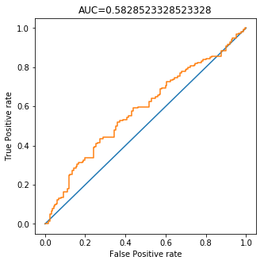

```python
plot_roc_curve(clf_rf_best, X_test, 5)
```

```python
from sklearn.metrics import confusion_matrix

def plot_confusion_matrix(cm, classes,
                          normalize=False,
                          title='Confusion matrix',
                          cmap=plt.cm.Blues):
    """
    This function prints and plots the confusion matrix.
    Normalization can be applied by setting `normalize=True`.
    """
    if normalize:
        cm = cm.astype('float') / cm.sum(axis=1)[:, np.newaxis]
        print("Normalized confusion matrix")
    else:
        print('Confusion matrix, without normalization')

    plt.imshow(cm, interpolation='nearest', cmap=cmap)
    plt.title(title)
    plt.colorbar()
    tick_marks = np.arange(len(classes))
    plt.xticks(tick_marks, classes, rotation=45)
    plt.yticks(tick_marks, classes)

    fmt = '.2f' if normalize else 'd'
    thresh = cm.max() / 2.
    for i, j in itertools.product(range(cm.shape[0]), range(cm.shape[1])):
        plt.text(j, i, format(cm[i, j], fmt),
                 horizontalalignment="center",
                 color="white" if cm[i, j] > thresh else "black")

    plt.tight_layout()
    plt.ylabel('True label')
    plt.xlabel('Predicted label')
```

```
Normalized confusion matrix
```

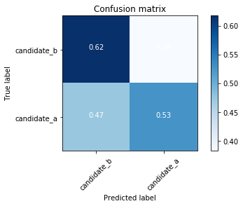

```python
cm = confusion_matrix(y_test, y_predicted_rf)

plot_confusion_matrix(cm,classes=['candidate_b','candidate_a'],normalize=True)
plt.show()
```

## 3.3 SVM Model

- Effective in high dimensional spaces.
- Versatile: different Kernel functions (linear and unlinear) can be specified for the decision function.

### Normalization And Dimensionality Reduction (PCA)

```python
X = df.dropna().drop(["prim_id",'support'], axis=1)
Y = df['support']

scaler = StandardScaler().fit(X)
X = pd.DataFrame(scaler.transform(X), columns = X.columns)
```

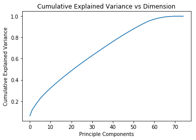

```python
pca = PCA()
pca.fit(X)
cummulative_explained_variance_ = np.cumsum(pca.explained_variance_ratio_)
plt.plot(range(len(cummulative_explained_variance_)), cummulative_explained_variance_)
plt.xlabel('Principle Components')
plt.ylabel('Cumulative Explained Variance')
plt.title('Cumulative Explained Variance vs Dimension')
plt.show()
plt.clf()
```

**Choose reduce to 45 principle components, that is around 80% cumulative explained variance**

```python
pca = PCA(45)
pca.fit(X)
X_svm = pca.transform(X)
print(X_svm.shape)
df_svm = pd.DataFrame(np.column_stack([X_svm, Y]), columns=['PCA '+str(x) for x in range(1,46)]+['support'] )
pca.explained_variance_ratio_.sum()
```

```
(1577, 45)
```

```
0.80821294414173728
```

```python
df_svm.head()
```

|  | PCA 1 | PCA 2 | PCA 3 | PCA 4 | PCA 5 | PCA 6 | PCA 7 | PCA 8 | PCA 9 | PCA 10 | ... | PCA 37 | PCA 38 | PCA 39 | PCA 40 | PCA 41 | PCA 42 | PCA 43 | PCA 44 | PCA 45 | support |
| --- | --- | --- | --- | --- | --- | --- | --- | --- | --- | --- | --- | --- | --- | --- | --- | --- | --- | --- | --- | --- | --- |
| 0 | -1.862001 | 0.783019 | -1.225753 | -1.111189 | 0.133515 | 0.220126 | 0.834308 | 1.073718 | -0.397098 | -0.407884 | ... | -0.018247 | 0.049801 | 0.270386 | 0.238115 | -0.385999 | 0.090925 | -0.018752 | 0.244876 | -0.285676 | 0.0 |
| 1 | -2.309573 | 1.646856 | -0.785610 | -1.378448 | 0.137966 | 0.102142 | 0.890861 | 0.814513 | -0.331962 | -0.620503 | ... | 0.205085 | 0.543154 | 0.199606 | 0.252061 | -0.431462 | 0.040397 | 0.095448 | 0.026478 | -0.396895 | 0.0 |
| 2 | 2.511855 | 4.155563 | 0.988246 | -2.627793 | -0.008718 | -0.513912 | -1.292934 | 0.971739 | 0.050046 | 0.014417 | ... | 0.104967 | 0.165172 | 0.688675 | 1.298119 | 0.217477 | -1.348050 | 0.350951 | -0.695622 | 0.968000 | 1.0 |
| 3 | -2.352314 | 0.793790 | 3.495091 | -0.476803 | 0.328540 | -0.953686 | 0.226363 | -2.404602 | 0.351295 | -0.863645 | ... | -0.210969 | -0.166935 | -0.071342 | 0.427227 | 0.003758 | 0.224153 | 0.379742 | -0.379129 | 0.103070 | 1.0 |
| 4 | 4.069763 | 0.617822 | -2.133848 | -1.945480 | -0.236878 | -0.006080 | 2.051953 | -1.074396 | -0.474288 | 0.685822 | ... | -0.025366 | -0.069464 | -0.419019 | -0.201553 | 0.031156 | -0.018684 | 0.287082 | -0.112416 | -0.237260 | 1.0 |

5 rows × 46 columns

### Train Test Split

```python
train_svm, test_svm = train_test_split(df_svm, test_size=0.2, random_state=10
                                     ,stratify=df['support'])# stratify the outcome

features = [x for x in train_svm.columns if x not in ['support']]

X_train_svm = train_svm[features]
X_test_svm = test_svm[features]
y_train_svm = train_svm['support']
y_test_svm = test_svm['support']
```

### SVM with different non-linear kernels

```python
# RBF kernel
from sklearn import svm

svm_rbf = svm.SVC(kernel='rbf', probability=True)
svm_rbf.fit(X_train_svm, y_train_svm)

y_predicted_svm_rbf = svm_rbf.predict(X_test_svm)
accuracy, precision, recall, f1 = get_metrics(y_test_svm, y_predicted_svm_rbf)
print("accuracy = %.3f, precision = %.3f, recall = %.3f, f1 = %.3f" % (accuracy, precision, recall, f1))
```

```
accuracy = 0.547, precision = 0.548, recall = 0.547, f1 = 0.537
```

```python
# poly kernel

svm_poly = svm.SVC(kernel='poly', probability=True)
svm_poly.fit(X_train_svm, y_train_svm)

y_predicted_svm_poly = svm_poly.predict(X_test_svm)
accuracy, precision, recall, f1 = get_metrics(y_test_svm, y_predicted_svm_poly)
print("accuracy = %.3f, precision = %.3f, recall = %.3f, f1 = %.3f" % (accuracy, precision, recall, f1))
```

```
accuracy = 0.547, precision = 0.555, recall = 0.547, f1 = 0.515
```

```python
# RBF kenerl hyperparameters

C_range = [0.01,0.03,0.1,0.3,1,3,10,30,100,300,1000]
gamma_range = [0.0001,0.0003,0.001,0.003,0.01,0.03,1]

param_grid = dict(gamma=gamma_range, C=C_range)

grid = GridSearchCV(svm.SVC(kernel='rbf'), param_grid=param_grid, cv=5)
grid.fit(X_train_svm, y_train_svm)
```

```
GridSearchCV(cv=5, error_score='raise',
       estimator=SVC(C=1.0, cache_size=200, class_weight=None, coef0=0.0,
  decision_function_shape='ovr', degree=3, gamma='auto', kernel='rbf',
  max_iter=-1, probability=False, random_state=None, shrinking=True,
  tol=0.001, verbose=False),
       fit_params={}, iid=True, n_jobs=1,
       param_grid={'gamma': [0.0001, 0.0003, 0.001, 0.003, 0.01, 0.03, 1], 'C': [0.01, 0.03, 0.1, 0.3, 1, 3, 10, 30, 100, 300, 1000]},
       pre_dispatch='2*n_jobs', refit=True, scoring=None, verbose=0)
```

```python
svm_best = grid.best_estimator_
svm_best
```

```
SVC(C=0.1, cache_size=200, class_weight=None, coef0=0.0,
  decision_function_shape='ovr', degree=3, gamma=0.01, kernel='rbf',
  max_iter=-1, probability=False, random_state=None, shrinking=True,
  tol=0.001, verbose=False)
```

```python
svm_best.fit(X_train_svm, y_train_svm)

y_predicted_svm_best = svm_best.predict(X_test_svm)
accuracy, precision, recall, f1 = get_metrics(y_test_svm, y_predicted_svm_best)
print("accuracy = %.3f, precision = %.3f, recall = %.3f, f1 = %.3f" % (accuracy, precision, recall, f1))
```

```
accuracy = 0.570, precision = 0.573, recall = 0.570, f1 = 0.559
```

### Model Inspection

```
Normalized confusion matrix
```

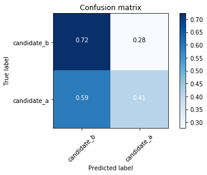

```python
cm = confusion_matrix(y_test, y_predicted_svm_best)

plot_confusion_matrix(cm,classes=['candidate_b','candidate_a'],normalize=True)
plt.show()
```

**SVM may not be a good choice!**

# 4. Modeling (with graph feature)

## 4.1 Feature Engineering - Simple Graph Statistic Feature

Statistical Features:

- relation_count: count of relations ('sink's) in the graph data
- relation_sum: sum of strength of all relationships
- relation_mean: mean strength of relationship

```python
dfg = df.copy() # dfg: df with graph features
```

```python
def calc_relation_count(source_id):
    return graph_df[graph_df['source'] == source_id]['sink'].count()

def calc_relation_sum(source_id):
    return graph_df[graph_df['source'] == source_id]['relationship_score'].sum()

def calc_relation_mean(source_id):
    return graph_df[graph_df['source'] == source_id]['relationship_score'].mean()
```

```python
dfg['relation_count'] = dfg['prim_id'].apply(lambda x: calc_relation_count(x))
dfg['relation_sum'] = dfg['prim_id'].apply(lambda x: calc_relation_sum(x))
dfg['relation_mean'] = dfg['prim_id'].apply(lambda x: calc_relation_mean(x))
dfg.loc[dfg.relation_mean.isnull(), 'relation_mean'] = 0
```

```python
dfg.head()
```

|  | prim_id | support | la1 | la3 | voted_03_05_2013 | voted_05_21_2013 | voted_06_07_2016 | demplus | age | repplus | ... | ethnic_R | ethnic_S | ethnic_U | ethnic_V | ethnic_W | ethnic_X | ethnic_Y | relation_count | relation_sum | relation_mean |
| --- | --- | --- | --- | --- | --- | --- | --- | --- | --- | --- | --- | --- | --- | --- | --- | --- | --- | --- | --- | --- | --- |
| 0 | 19523066036 | 0 | 0 | 1 | 0 | 0 | 1 | 1 | 51.0 | 0 | ... | 0 | 0 | 0 | 0 | 0 | 1 | 0 | 0 | 0.0 | 0.0 |
| 1 | 19523244550 | 0 | 0 | 0 | 0 | 0 | 1 | 1 | 53.0 | 0 | ... | 0 | 0 | 0 | 0 | 0 | 1 | 0 | 0 | 0.0 | 0.0 |
| 2 | 19491481087 | 1 | 0 | 0 | 0 | 0 | 0 | 0 | 59.0 | 1 | ... | 0 | 1 | 0 | 0 | 0 | 0 | 0 | 0 | 0.0 | 0.0 |
| 3 | 19526211987 | 1 | 0 | 0 | 0 | 0 | 1 | 1 | 23.0 | 0 | ... | 0 | 0 | 0 | 0 | 0 | 0 | 0 | 2 | 2.0 | 1.0 |
| 4 | 19214836641 | 1 | 1 | 1 | 1 | 1 | 1 | 0 | 79.0 | 1 | ... | 0 | 0 | 0 | 0 | 0 | 1 | 0 | 0 | 0.0 | 0.0 |

5 rows × 80 columns

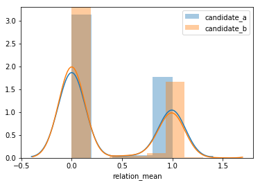

```python
f, ax = plt.subplots(1, 1)
sns.distplot(dfg['relation_mean'][dfg['support']==1], label='candidate_a')
sns.distplot(dfg['relation_mean'][dfg['support']==0], label='candidate_b')
ax.legend()
```

## 4.2 Feature Engineering - Support Candidate A Probability from Graph Relationships

First predict probability of support candidate A (prob_a) of each voter by previous random forest model (without graph feature). Then create two new features:

- relation_prob_a_rf_avg: for a particular source, this is the average of sink_prob_a_rf for all related sinks.
- relation_prob_a_rf_weighted_avg: for a particular source, this is the weighted average of sink_prob_a_rf for all related sinks. Here 'weight' is the strength of the relationship.

Note that graph_df has more voters prim_id than that in voters_df, for those without voters feature, I'll assign a prob_a = 0.5.

### Process voters_df

```python
def binary_category_to_numeric2(df):
    """
    Change binary category data to 0/1 numeric features.
    """
    #df['support'] = df['support'].map({'candidate_b':0, 'candidate_a':1}) # 0 for support b, 1 for a
    df['demplus'] = df['demplus'].map({'N':0, 'Y':1}) # 0 for N, 1 for Y
    df['repplus'] = df['repplus'].map({'N':0, 'Y':1}) # 0 for N, 1 for Y
    df['ismarried'] = df['ismarried'].map({'N':0, 'Y':1}) # 0 for N, 1 for Y
    df['home'] = df['home'].map({'N':0, 'H':1}) # 0 for N, 1 for H
    df['renters'] = df['renters'].map({'N':0, 'Y':1}) # 0 for N, 1 for Y
    df['sex'] = df['sex'].map({'F':0, 'M':1}) # 0 for F, 1 for M
    df.loc[df.sex.isnull(), 'sex'] = 0.5 # set not known sex = 0.5
```

```python
# Process voters_df same as we did for merged support data (df) before.
vdf = voters_df.copy()
clean_missing_category(vdf)
binary_category_to_numeric2(vdf)
vdf = pd.get_dummies(vdf) # one-hot encoding
print(vdf.shape)
vdf.head()
```

```
(434624, 90)
```

|  | prim_id | la1 | la3 | voted_03_05_2013 | voted_05_21_2013 | voted_06_07_2016 | demplus | age | repplus | ismarried | ... | ethnic_P | ethnic_R | ethnic_S | ethnic_T | ethnic_U | ethnic_V | ethnic_W | ethnic_X | ethnic_Y | ethnic_Z |
| --- | --- | --- | --- | --- | --- | --- | --- | --- | --- | --- | --- | --- | --- | --- | --- | --- | --- | --- | --- | --- | --- |
| 0 | 19101063480 | 0 | 1 | 1 | 0 | 1 | 0 | 42.0 | 1 | 1 | ... | 0 | 0 | 0 | 0 | 0 | 0 | 0 | 1 | 0 | 0 |
| 1 | 19101122779 | 0 | 0 | 0 | 0 | 1 | 1 | 53.0 | 0 | 0 | ... | 0 | 0 | 0 | 0 | 0 | 0 | 0 | 1 | 0 | 0 |
| 2 | 19101930697 | 1 | 1 | 1 | 1 | 1 | 1 | 70.0 | 0 | 0 | ... | 0 | 0 | 0 | 0 | 0 | 0 | 0 | 1 | 0 | 0 |
| 3 | 19102226061 | 0 | 0 | 0 | 0 | 0 | 0 | 57.0 | 1 | 0 | ... | 0 | 0 | 0 | 0 | 0 | 0 | 0 | 0 | 0 | 0 |
| 4 | 19104235280 | 0 | 0 | 0 | 0 | 0 | 0 | 51.0 | 0 | 1 | ... | 0 | 0 | 0 | 0 | 0 | 0 | 0 | 1 | 0 | 0 |

5 rows × 90 columns

```python
# impute age as mean age in voters data
vdf.loc[vdf.age.isnull(), 'age'] = vdf['age'].mean()
```

### Predict voters probability of support candidate A by previous best Random Forest Model

```python
clf_rf_best
```

```
RandomForestClassifier(bootstrap=True, class_weight=None, criterion='gini',
            max_depth=10, max_features='sqrt', max_leaf_nodes=None,
            min_impurity_decrease=0.0, min_impurity_split=None,
            min_samples_leaf=3, min_samples_split=2,
            min_weight_fraction_leaf=0.0, n_estimators=150, n_jobs=-1,
            oob_score=False, random_state=0, verbose=0, warm_start=False)
```

```python
features = [x for x in train.columns if x not in ['prim_id', 'support']]
prob_a_rf_predict = clf_rf_best.predict_proba(vdf[features])[:,1]
```

```python
vdf['prob_a_rf'] = prob_a_rf_predict
```

```python
vdf.head()
```

|  | prim_id | la1 | la3 | voted_03_05_2013 | voted_05_21_2013 | voted_06_07_2016 | demplus | age | repplus | ismarried | ... | ethnic_R | ethnic_S | ethnic_T | ethnic_U | ethnic_V | ethnic_W | ethnic_X | ethnic_Y | ethnic_Z | prob_a_rf |
| --- | --- | --- | --- | --- | --- | --- | --- | --- | --- | --- | --- | --- | --- | --- | --- | --- | --- | --- | --- | --- | --- |
| 0 | 19101063480 | 0 | 1 | 1 | 0 | 1 | 0 | 42.0 | 1 | 1 | ... | 0 | 0 | 0 | 0 | 0 | 0 | 1 | 0 | 0 | 0.659616 |
| 1 | 19101122779 | 0 | 0 | 0 | 0 | 1 | 1 | 53.0 | 0 | 0 | ... | 0 | 0 | 0 | 0 | 0 | 0 | 1 | 0 | 0 | 0.373042 |
| 2 | 19101930697 | 1 | 1 | 1 | 1 | 1 | 1 | 70.0 | 0 | 0 | ... | 0 | 0 | 0 | 0 | 0 | 0 | 1 | 0 | 0 | 0.305532 |
| 3 | 19102226061 | 0 | 0 | 0 | 0 | 0 | 0 | 57.0 | 1 | 0 | ... | 0 | 0 | 0 | 0 | 0 | 0 | 0 | 0 | 0 | 0.607667 |
| 4 | 19104235280 | 0 | 0 | 0 | 0 | 0 | 0 | 51.0 | 0 | 1 | ... | 0 | 0 | 0 | 0 | 0 | 0 | 1 | 0 | 0 | 0.665810 |

5 rows × 91 columns

### Add 'sink' prob_a_rf to the graph data.

```python
df_ = vdf[['prim_id','prob_a_rf']]
graph_df = pd.merge(graph_df, df_, left_on=['sink'], right_on=['prim_id'], how='left')
graph_df = graph_df.drop(columns=['prim_id'])
graph_df.loc[graph_df.prob_a_rf.isnull(), 'prob_a_rf'] = 0.5
graph_df=graph_df.rename(columns = {'prob_a_rf':'sink_prob_a_rf'})
graph_df
graph_df.head()
```

|  | relationship_score | source | sink | sink_prob_a_rf |
| --- | --- | --- | --- | --- |
| 0 | 1.0 | 19523849390 | 19522824197 | 0.500000 |
| 1 | 1.0 | 19527100653 | 19522824197 | 0.500000 |
| 2 | 1.0 | 19524239271 | 19522824197 | 0.500000 |
| 3 | 1.0 | 19524497774 | 19522824197 | 0.500000 |
| 4 | 1.0 | 19223246835 | 19522658525 | 0.424795 |

### Create relation_prob_a_rf_avg feature

For a particular source, this is the average of sink_prob_a_rf for all related sinks.

```python
def calc_relation_prob_avg(source_id, prob_type):
    return graph_df[graph_df['source'] == source_id][prob_type].mean()

dfg['relation_prob_a_rf_avg'] = dfg['prim_id'].apply(lambda x: calc_relation_prob_avg(x, 'sink_prob_a_rf'))
dfg.loc[dfg.relation_prob_a_rf_avg.isnull(), 'relation_prob_a_rf_avg'] = 0.5
```

### Create relation_prob_a_rf_weighted_avg

For a particular source, this is the weighted average of sink_prob_a_rf for all related sinks. Here 'weight' is the strength of the relationship.

```python
def calc_relation_prob_a_weighted_avg(source_id, prob_type):
    df_ = graph_df[graph_df['source'] == source_id]
    sum_ = 0
    prob_sum = 0
    for i in range(df_.shape[0]):
        rel = df_.iloc[i]['relationship_score']
        prob = df_.iloc[i][prob_type]
        sum_ += rel
        prob_sum += rel * prob

    if sum_ == 0:
        return 0.5
    return prob_sum / sum_

dfg['relation_prob_a_rf_weighted_avg'] = dfg['prim_id'].apply(lambda x: calc_relation_prob_a_weighted_avg(x, 'sink_prob_a_rf'))
```

```python
dfg.head()
```

|  | prim_id | support | la1 | la3 | voted_03_05_2013 | voted_05_21_2013 | voted_06_07_2016 | demplus | age | repplus | ... | ethnic_U | ethnic_V | ethnic_W | ethnic_X | ethnic_Y | relation_count | relation_sum | relation_mean | relation_prob_a_rf_avg | relation_prob_a_rf_weighted_avg |
| --- | --- | --- | --- | --- | --- | --- | --- | --- | --- | --- | --- | --- | --- | --- | --- | --- | --- | --- | --- | --- | --- |
| 0 | 19523066036 | 0 | 0 | 1 | 0 | 0 | 1 | 1 | 51.0 | 0 | ... | 0 | 0 | 0 | 1 | 0 | 0 | 0.0 | 0.0 | 0.500000 | 0.500000 |
| 1 | 19523244550 | 0 | 0 | 0 | 0 | 0 | 1 | 1 | 53.0 | 0 | ... | 0 | 0 | 0 | 1 | 0 | 0 | 0.0 | 0.0 | 0.500000 | 0.500000 |
| 2 | 19491481087 | 1 | 0 | 0 | 0 | 0 | 0 | 0 | 59.0 | 1 | ... | 0 | 0 | 0 | 0 | 0 | 0 | 0.0 | 0.0 | 0.500000 | 0.500000 |
| 3 | 19526211987 | 1 | 0 | 0 | 0 | 0 | 1 | 1 | 23.0 | 0 | ... | 0 | 0 | 0 | 0 | 0 | 2 | 2.0 | 1.0 | 0.474415 | 0.474415 |
| 4 | 19214836641 | 1 | 1 | 1 | 1 | 1 | 1 | 0 | 79.0 | 1 | ... | 0 | 0 | 0 | 1 | 0 | 0 | 0.0 | 0.0 | 0.500000 | 0.500000 |

5 rows × 82 columns

## 4.3 Random Forest Model

### Train Test Split

```python
train, test = train_test_split(dfg, test_size=0.2, random_state=10
                                     ,stratify=dfg['support'])# stratify the outcome

features = [x for x in train.columns if x not in ['prim_id', 'support']]

X_train = train[features]
X_test = test[features]
y_train = train['support']
y_test = test['support']
```

### Grid Search and Cross Validation

```python
clf_rf = RandomForestClassifier(n_jobs=-1, max_features='sqrt', random_state=0)

# Use a grid over parameters of interest
param_grid = {
           "n_estimators" : [50, 100, 150, 200],
           "max_depth" : [5, 10, 20, 30],
           "min_samples_leaf" : [1, 3, 5]}

rf_cv = GridSearchCV(estimator=clf_rf, param_grid=param_grid, cv= 5)
rf_cv.fit(X_train, y_train)

clf_rf_best = rf_cv.best_estimator_
clf_rf_best
```

```
RandomForestClassifier(bootstrap=True, class_weight=None, criterion='gini',
            max_depth=10, max_features='sqrt', max_leaf_nodes=None,
            min_impurity_decrease=0.0, min_impurity_split=None,
            min_samples_leaf=3, min_samples_split=2,
            min_weight_fraction_leaf=0.0, n_estimators=50, n_jobs=-1,
            oob_score=False, random_state=0, verbose=0, warm_start=False)
```

```python
y_predicted_rf = clf_rf_best.predict(X_test)
accuracy, precision, recall, f1 = get_metrics(y_test, y_predicted_rf)
print("accuracy = %.3f, precision = %.3f, recall = %.3f, f1 = %.3f" % (accuracy, precision, recall, f1))
```

```
accuracy = 0.576, precision = 0.576, recall = 0.576, f1 = 0.575
```

### Feature Importance

```
Feature ranking:
1. feature age (0.151032)
2. feature relation_prob_a_rf_avg (0.116397)
3. feature relation_prob_a_rf_weighted_avg (0.082049)
4. feature relation_sum (0.037893)
5. feature sex (0.032220)
6. feature hhcount (0.031545)
7. feature party_D (0.028387)
8. feature demplus (0.026435)
9. feature relation_mean (0.024965)
10. feature repplus (0.024806)
11. feature relation_count (0.023914)
12. feature renters (0.023847)
13. feature abrscore_NOT_ABR (0.021586)
14. feature ethnic_X (0.020429)
15. feature home (0.019114)
16. feature voted_05_21_2013 (0.018619)
17. feature ethnic_NN (0.018552)
18. feature voted_03_05_2013 (0.018201)
19. feature la1 (0.017353)
20. feature abrscore_ML (0.015969)
21. feature voted_06_07_2016 (0.015802)
22. feature hpt_nt_A (0.015604)
23. feature abrscore_OL (0.015534)
24. feature abrscore_AL (0.015468)
25. feature ismarried (0.013295)
26. feature abrscore_ME (0.013233)
27. feature party_R (0.012890)
28. feature hpt_nt_K (0.012586)
29. feature ethnic_J (0.012107)
30. feature party_DS (0.011914)
31. feature hpt_nt_0 (0.011459)
32. feature hpt_nt_B (0.010363)
33. feature la3 (0.009087)
34. feature hpt_nt_S (0.008895)
35. feature hpt_nt_C (0.008638)
36. feature ethnic_S (0.006375)
37. feature abrscore_AE (0.006282)
38. feature hpt_nt_T (0.006093)
39. feature hpt_nt_R (0.005674)
```

[output cut: 26 more lines]

```
66. feature ethnic_R (0.000000)
67. feature ethnic_K (0.000000)
68. feature ethnic_M (0.000000)
69. feature hpt_nt_Z (0.000000)
70. feature hpt_nt_U (0.000000)
71. feature hpt_nt_Q (0.000000)
72. feature hpt_nt_L (0.000000)
73. feature ethnic_L (0.000000)
74. feature hpt_nt_I (0.000000)
75. feature hpt_nt_G (0.000000)
76. feature hpt_nt_E (0.000000)
77. feature hpt_nt_2 (0.000000)
78. feature hpt_nt_4 (0.000000)
79. feature hpt_nt_6 (0.000000)
80. feature party_PF (0.000000)
```

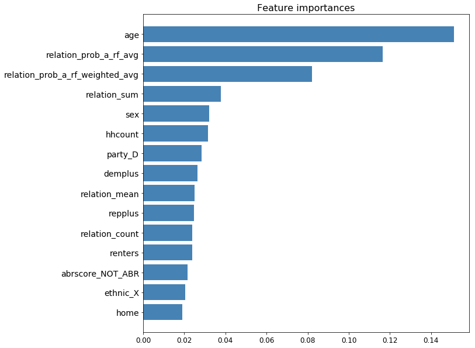

```python
plot_feature_importance(clf_rf_best, X_train.columns, X_train, 15, 8)
```

### Model Evaluation

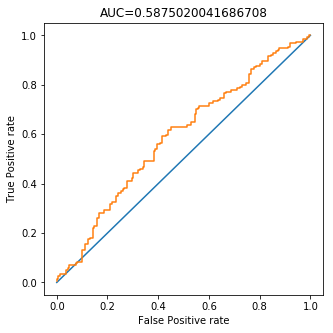

```python
plot_roc_curve(clf_rf_best, X_test, 5)
```

```
Normalized confusion matrix
```

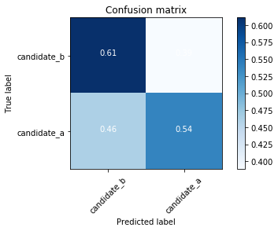

```python
cm = confusion_matrix(y_test, y_predicted_rf)

plot_confusion_matrix(cm,classes=['candidate_b','candidate_a'],normalize=True)
plt.show()
```

## 4.4 SVM Model

### Try RBF Model

```python
svm_rbf = svm.SVC(kernel='rbf', probability=True)
svm_rbf.fit(X_train_svm, y_train_svm)

y_predicted_svm_rbf = svm_rbf.predict(X_test_svm)
accuracy, precision, recall, f1 = get_metrics(y_test_svm, y_predicted_svm_rbf)
print("accuracy = %.3f, precision = %.3f, recall = %.3f, f1 = %.3f" % (accuracy, precision, recall, f1))
```

```
accuracy = 0.547, precision = 0.548, recall = 0.547, f1 = 0.537
```

```python
# RBF kenerl hyperparameters

C_range = [0.01,0.03,0.1,0.3,1,3,10,30,100,300,1000]
gamma_range = [0.0001,0.0003,0.001,0.003,0.01,0.03,1]

param_grid = dict(gamma=gamma_range, C=C_range)

grid = GridSearchCV(svm.SVC(kernel='rbf'), param_grid=param_grid, cv=5)
grid.fit(X_train_svm, y_train_svm)
```

```
GridSearchCV(cv=5, error_score='raise',
       estimator=SVC(C=1.0, cache_size=200, class_weight=None, coef0=0.0,
  decision_function_shape='ovr', degree=3, gamma='auto', kernel='rbf',
  max_iter=-1, probability=False, random_state=None, shrinking=True,
  tol=0.001, verbose=False),
       fit_params={}, iid=True, n_jobs=1,
       param_grid={'gamma': [0.0001, 0.0003, 0.001, 0.003, 0.01, 0.03, 1], 'C': [0.01, 0.03, 0.1, 0.3, 1, 3, 10, 30, 100, 300, 1000]},
       pre_dispatch='2*n_jobs', refit=True, scoring=None, verbose=0)
```

```python
svm_best = grid.best_estimator_
svm_best
```

```
SVC(C=0.1, cache_size=200, class_weight=None, coef0=0.0,
  decision_function_shape='ovr', degree=3, gamma=0.01, kernel='rbf',
  max_iter=-1, probability=False, random_state=None, shrinking=True,
  tol=0.001, verbose=False)
```

```python
svm_best.fit(X_train_svm, y_train_svm)
y_predicted_svm_best = svm_best.predict(X_test_svm)

accuracy, precision, recall, f1 = get_metrics(y_test_svm, y_predicted_svm_best)
print("accuracy = %.3f, precision = %.3f, recall = %.3f, f1 = %.3f" % (accuracy, precision, recall, f1))
```

```
accuracy = 0.570, precision = 0.573, recall = 0.570, f1 = 0.559
```

```
Normalized confusion matrix
```

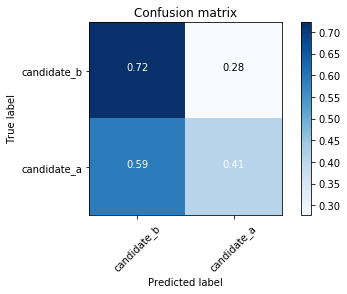

```python
cm = confusion_matrix(y_test, y_predicted_svm_best)

plot_confusion_matrix(cm,classes=['candidate_b','candidate_a'],normalize=True)
plt.show()
```

# 5. Final Output

Use Random Forest model with graph features.

```python
# Create Statistical Graph Feature
vdfg = vdf.copy() # voters dat with graph feature
vdfg['relation_count'] = vdfg['prim_id'].apply(lambda x: calc_relation_count(x))
vdfg['relation_sum'] = vdfg['prim_id'].apply(lambda x: calc_relation_sum(x))
vdfg['relation_mean'] = vdfg['prim_id'].apply(lambda x: calc_relation_mean(x))
vdfg.loc[vdfg.relation_mean.isnull(), 'relation_mean'] = 0
```

```python
# Create Relational Candidate A support probability features

# relation_prob_a_rf_avg feature
vdfg['relation_prob_a_rf_avg'] = vdfg['prim_id'].apply(lambda x: calc_relation_prob_avg(x, 'sink_prob_a_rf'))
vdfg.loc[vdfg.relation_prob_a_rf_avg.isnull(), 'relation_prob_a_rf_avg'] = 0.5

# relation_prob_a_rf_weighted_avg feature
vdfg['relation_prob_a_rf_weighted_avg'] = vdfg['prim_id'].apply(lambda x: calc_relation_prob_a_weighted_avg(x, 'sink_prob_a_rf'))
```

```python
# Apply Best Random Forest Model
features = [x for x in dfg.columns if x not in ['prim_id', 'support']]

candidate_a_support_proba = clf_rf_best.predict_proba(vdfg[features])[:,1]
vdfg['candidate_a_support_proba'] = candidate_a_support_proba
```

```python
vdfg.head()
```

|  | prim_id | la1 | la3 | voted_03_05_2013 | voted_05_21_2013 | voted_06_07_2016 | demplus | age | repplus | ismarried | ... | ethnic_X | ethnic_Y | ethnic_Z | prob_a_rf | relation_count | relation_sum | relation_mean | relation_prob_a_rf_avg | relation_prob_a_rf_weighted_avg | candidate_a_support_proba |
| --- | --- | --- | --- | --- | --- | --- | --- | --- | --- | --- | --- | --- | --- | --- | --- | --- | --- | --- | --- | --- | --- |
| 0 | 19101063480 | 0 | 1 | 1 | 0 | 1 | 0 | 42.0 | 1 | 1 | ... | 1 | 0 | 0 | 0.659616 | 3 | 2.60484 | 0.86828 | 0.615895 | 0.633476 | 0.700124 |
| 1 | 19101122779 | 0 | 0 | 0 | 0 | 1 | 1 | 53.0 | 0 | 0 | ... | 1 | 0 | 0 | 0.373042 | 0 | 0.00000 | 0.00000 | 0.500000 | 0.500000 | 0.380818 |
| 2 | 19101930697 | 1 | 1 | 1 | 1 | 1 | 1 | 70.0 | 0 | 0 | ... | 1 | 0 | 0 | 0.305532 | 0 | 0.00000 | 0.00000 | 0.500000 | 0.500000 | 0.325681 |
| 3 | 19102226061 | 0 | 0 | 0 | 0 | 0 | 0 | 57.0 | 1 | 0 | ... | 0 | 0 | 0 | 0.607667 | 0 | 0.00000 | 0.00000 | 0.500000 | 0.500000 | 0.560130 |
| 4 | 19104235280 | 0 | 0 | 0 | 0 | 0 | 0 | 51.0 | 0 | 1 | ... | 1 | 0 | 0 | 0.665810 | 1 | 1.00000 | 1.00000 | 0.684526 | 0.684526 | 0.758502 |

5 rows × 97 columns

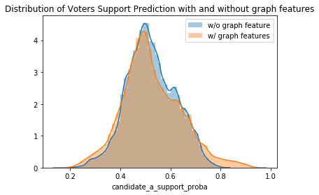

```python
# Plot RF (no graph feature) predicted candidate A support probabilities
f, ax = plt.subplots(1, 1)
sns.distplot(vdfg['prob_a_rf'], label='w/o graph feature')
sns.distplot(vdfg['candidate_a_support_proba'], label='w/ graph features')
plt.title("Distribution of Voters Support Prediction with and without graph features")
ax.legend()
```

```python
# Output Result
vdfg[['prim_id','candidate_a_support_proba']].to_csv('support_probabilities.csv', sep='\t', encoding='utf-8', index=False)
```